# Função loop For

Daniel Maurenza de Oliveira

https://github.com/dmaurenza/Curso-Intermediario-R

Nesta aula vamos aprender a usar uma das funções loop. As funções loop são usadas para aplicar a mesma tarefa para um dado conjunto de dados de acordo com os níveis de um fator. Existem diversas funções loop, mas nós vamos focar na função loop “for”,

# Elementos da Aula

1. Loop “for” em Vetores
2. Loop “for” em Dataframes

## Loop “for” em Vetores

As funções loop servem para que um determinado comando (ou conjunto de comandos) aplicado para um nível de um fator seja executado repetidamente aos outros níveis. É como se para cada nível de um fator elas aplicassem uma tarefa, fossem para outro nível, repetissem a mesma tarefa; corresse para o próximo nível, repetisse a mesma tarefa; por aí vai…

A função loop “for” funciona da seguinte maneira: for(var in seq) {command}. Ou seja, para cada valor de “var” dentro de “seq”, o R executa os comandos que estão entre as chaves.

No nosso primeiro contato com a esta função, vamos pedir que o R print (imprimir) números em uma sequência.

```r
for (i in 1:10) {
  print(i)
}
```

```
## [1] 1
## [1] 2
## [1] 3
## [1] 4
## [1] 5
## [1] 6
## [1] 7
## [1] 8
## [1] 9
## [1] 10
```

Vamos ver o que o “for” está fazendo em câmera lenta

```r
for (i in 1:10) {
  print(i)
  Sys.sleep(time = 1)
}
```

```
## [1] 1
## [1] 2
## [1] 3
## [1] 4
## [1] 5
## [1] 6
## [1] 7
## [1] 8
## [1] 9
## [1] 10
```

Um exemplo com letras

```r
x <- letters[1:4]

for (i in seq_along(along.with = x)) {
  print(x[i])
  Sys.sleep(time = 1)
}
```

```
## [1] "a"
## [1] "b"
## [1] "c"
## [1] "d"
```

Outro exemplo

```r
library(tidyverse)
alunos <- read_csv("dados/alunos_alterado.csv")
alunos
```

```
## # A tibble: 4 × 10
##   nome              idade sexo  altura  peso trans…¹ semes…²    pe   mao inici…³
##   <chr>             <dbl> <chr>  <dbl> <dbl> <chr>     <dbl> <dbl> <dbl> <lgl>
## 1 Daniel Maurenza …    39 M       1.7     72 Publico       5    40    22 TRUE
## 2 Maria                20 F       1.58    49 Publico       4    35    20 FALSE
## 3 Joao                 40 M       1.8     90 Privado       5    37    20 FALSE
## 4 Joana                25 F       1.75    65 Publico       1    33    21 TRUE
## # … with abbreviated variable names ¹transporte, ²semestre, ³iniciante
```

```r
alunos$nome
```

```
## [1] "Daniel Maurenza de Oliveira" "Maria"
## [3] "Joao"                        "Joana"
```

```r
for (i in alunos$nome){
  print(i)
}
```

```
## [1] "Daniel Maurenza de Oliveira"
## [1] "Maria"
## [1] "Joao"
## [1] "Joana"
```

```r
for (i in alunos$nome){
  print(paste("aluno", i))
}
```

```
## [1] "aluno Daniel Maurenza de Oliveira"
## [1] "aluno Maria"
## [1] "aluno Joao"
## [1] "aluno Joana"
```

Ou seja, pedimos ao R para na linha i, printar o nome i da planilha alunos. Neste caso, o tamanho de i é igual ao tamanho de alunos$nome

Vamos ver uma outra forma que talvez seja mais facil de entender. No argumento seq, nós vamos utilizar a expressão 1:n. Ou seja, for(i in 1:n) {comandos}. A expressão “i in 1:n” indica que os valores de i serão de i = 1 até i = n. Assim, na primeira rodada i = 1, na segunda i = 2, e assim por diante até que i = n.

Primeiro precisamos criar um objeto vazio para armazenar o resultado da operação. Vamos criar um objeto numérico vazio, chamado “resu” (abreviação de resultado). Depois, vamos executar para cada linha de “resu” uma operação matemática

```r
resu <- numeric(0)
resu
```

```
## numeric(0)
```

```r
for (i in 1:5) { # será o i = 1, i = 2, i = 3, i = 4, i = 5
  resu[i] <- i^2 # realiza a operação e armazena no vetor resu
} # fim da função
resu
```

```
## [1]  1  4  9 16 25
```

Outro exemplo. Vamos pedir para o R multiplicar a idade de cada aluno por 2

```r
idade <- alunos$idade

idade_x2 <- numeric()

for (i in 1:length(idade)) { # será o i = idade [1], i = idade [2], i = idade [3], i = idade [n]
  idade_x2[i] <- idade [i] * 2 # realiza a operação e armazena no vetor idade_x2
} # fim da função

idade
```

```
## [1] 39 20 40 25
```

```r
idade_x2
```

```
## [1] 78 40 80 50
```

Para não ficar dúvidas, vamos fazer um “filme” para demonstrar o que a função “for” está fazendo.

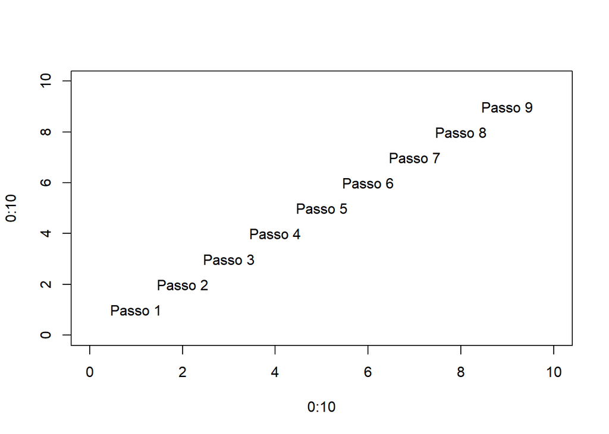

```r
plot(0:10,0:10, type="n") # plota um gráfico vazio

for (i in 1:9) {
  text(i,i, paste("Passo", i)) # plota um texto no gráfico
  Sys.sleep(1) ## retarda os passos em 1 s
}
```

# Exercícios

1. A sequência de Fibonacci é uma sequência numérica conhecida na matemática. Os dois primeiros números da sequência são [1, 1]. Os números subsequentes são compostos pela soma dos dois números anteriores. Assim, o terceiro número da sequência de Fibonacci é 1 + 1 = 2, o quarto é 1 + 2 = 3, e assim por diante. Utilize a função loop “for” para descobrir os 12 primeiros números da sequência de Fibonacci
2. Mude os dois primeiros elementos da sequencia para 2 e 2
3. Mude os dois primeiros elementos da sequencia para 3 e 2
4. Modifique o código para que os valores sejam compostos pela diferença entre o primeiro e o segundo valor imediatamente anteriores.
5. Modifique o código para que os valores sejam compostos pela diferença entre os dois valores imediatamente anteriores somada ao terceiro valor imediatamente anterior. Faça inicialmente com que a sequencia comece com 3 valores [1,1,1]

#### Loop “for” em Dataframes

A sequência lógica para usarmos a função loop “for” em dataframes é similar à que usamos em vetores, porém, utilizando a indexação de dataframes .

```r
nome_pe_mao <- data.frame(nome = NA, pe = NA, mao = NA)

for(i in 1:nrow(alunos)){
  #i = 1
  nome_pe_mao[i, 1] <- alunos[i, "nome"]
  nome_pe_mao[i, 2] <- alunos[i, "pe"]
  nome_pe_mao[i, 3] <- alunos[i, "mao"]

}

nome_pe_mao
```

```
##                          nome pe mao
## 1 Daniel Maurenza de Oliveira 40  22
## 2                       Maria 35  20
## 3                        Joao 37  20
## 4                       Joana 33  21
```

Para exemplificarmos melhor, vamos fazer uma amostragem utilizando a função “for” para realizar sorteios e amostragens aleatóreas. Similar ao jogo da megasena. Desta vez vamos usar uma matrix, mas não se preocupe, a indexação de matrix é igual à de dataframe.

Vamos sortear 20 jogos da megasena e criar a matriz para armazenar os jogos

```r
njogos <- 20

numeros <- matrix(NA, nrow = 6, ncol = njogos)
```

Agora vamos sortear 20 jogos com 6 números que varia de 1 a 60

```r
for (i in 1:njogos) { # determina o número total de jogos sorteados

    numeros[, i] <- sample (1:60, 6) # realiza a amostragem de 6 números por jogo

}
numeros
```

```
##      [,1] [,2] [,3] [,4] [,5] [,6] [,7] [,8] [,9] [,10] [,11] [,12] [,13] [,14]
## [1,]   42   31   22   16   27    1   25   38   23     4    31    21     3    39
## [2,]   19   45   37   29   22   35   42   46   28     3    25    51     7    33
## [3,]   44    9   55   11   51   42    9   13   48    33    16     3    50    27
## [4,]   43   25   25   30    8   31   22   58   22    25    22    19    47     1
## [5,]    4   51   16   17    5   46   46   20    5    41     9     1    44    56
## [6,]   47   20   59   36   36   18   12    4   39    56    12    33    35    25
##      [,15] [,16] [,17] [,18] [,19] [,20]
## [1,]    12    60    28    40    42    10
## [2,]    20    20    11    38     6    48
## [3,]     4    58    25    31    52    18
## [4,]    42    35    49    22    59    15
## [5,]    46    29    43    14     4    46
## [6,]    39    19    14    51    36    42
```

Vamos ver o que aconteceu

```r
numeros <- matrix(NA, nrow = 6, ncol = njogos) # criar a matriz para armazenar os jogos

for (i in 1:njogos) { # determina o número total de jogos sorteados

  numeros[, i] <- sample (1:60, 6) # realiza a amostragem de 6 números por jogo
  print(numeros)
  Sys.sleep(0.3)

}
numeros
```

[output not shown]

Ou seja, foram amostrados aleatoriamente 6 números que variam de 1 a 60, e armazenados para cada coluna i do dataframe numeros ([,i]).

# Exercícios

6. Utilizando as funções “For” e “write_csv”, crie um arquivo .csv para cada coluna da planilha Alunos. Dica!!! utilize a função “paste” para nomear os arquivos que serão salvos em cada rodada do loop.